# Exploration of Tetrastichus planipennisi Morphometrics in Vermont

# Results

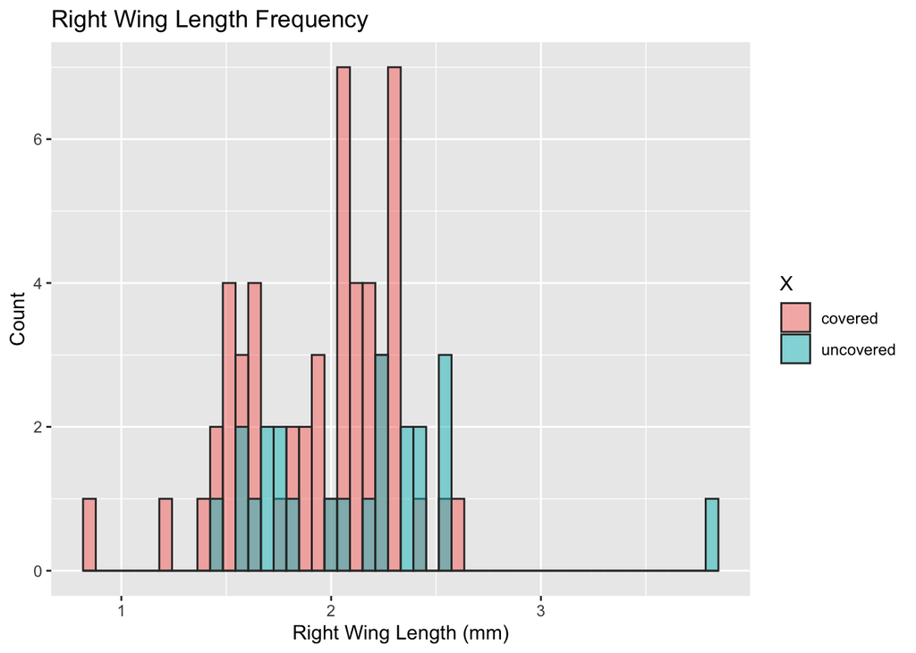

> **Figure 1** Overlapping histograms of covered and uncovered T. planipennisi right wing lengths (mm). The minimum value was 0.857701 mm. The maximum value was 3.825232 mm.

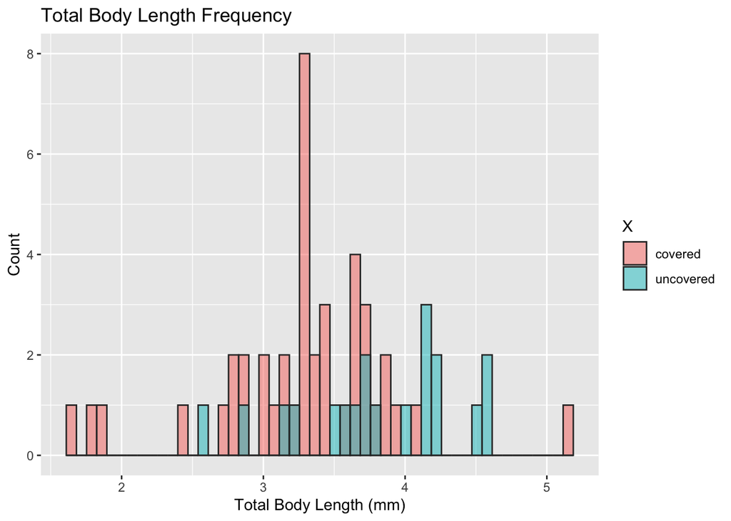

> **Figure 2** Overlapping histograms of covered and uncovered T. planipennisi total body lengths (mm). The minimum value was 1.676210 mm. The maximum value was 5.181705 mm.

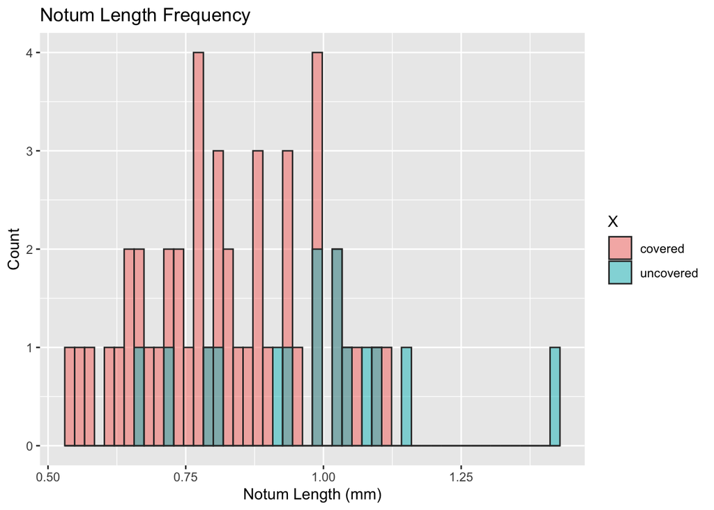

> **Figure 3** Overlapping histograms of covered and uncovered T. planipennisi notum lengths (mm). The minimum value was 0.539070 mm. The maximum value was 1.420035 mm.

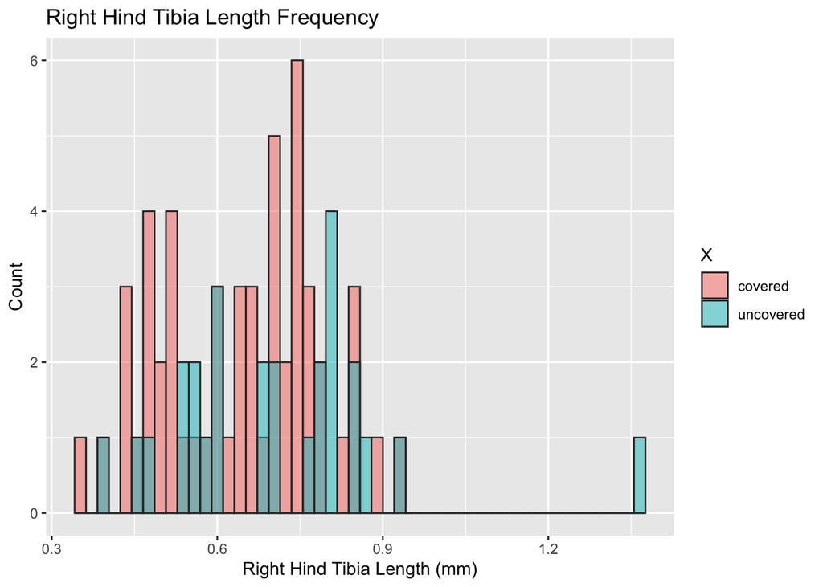

> **Figure 4** Overlapping histograms of covered and uncovered T. planipennisi right hind tibia lengths (mm). The minimum value was 0.356126 mm. The maximum value was 1.370109 mm.

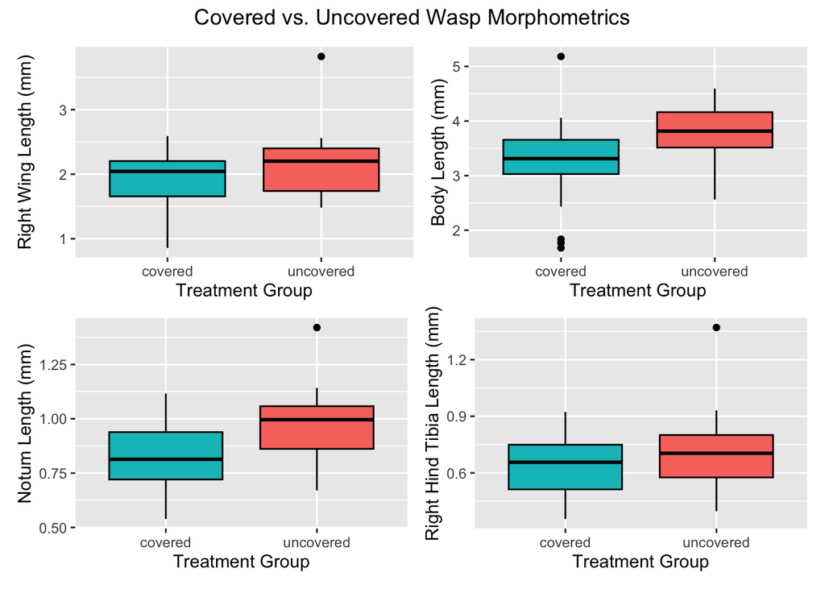

> **Figure 5** Box plots of T. planipennisi right wing, total body, notum, and right hind tibia lengths (mm) in different treatment groups (covered and uncovered).

Analyses of variance of mean body measurements between T. planipennisi covered and uncovered treatment groups found a statistically significant difference in the total body lengths (p=0.003) and notum lengths (p=0.00216) between the groups. These analyses did not reveal a statistically significant difference in the right wing lengths (p=0.0625) and right hind tibia lengths (p=0.0818) between the treatment groups.

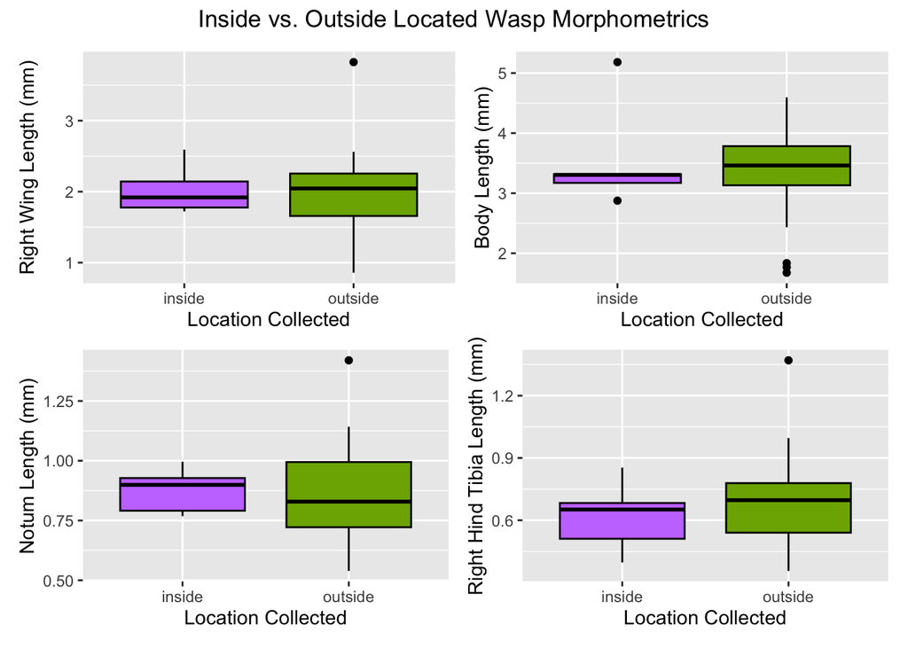

> **Figure 6** Box plots of T. planipennisi right wing, total body, notum, and right hind tibia lengths (mm) found inside and outside of the ash tree branches.

Analyses of variance of T. planipennisi mean body measurements among locations of collection (inside vs outside the branches) did not reveal a statistically significant difference in the right wing lengths (p=0.901), total body lengths (p=0.645), notum lengths (p=0.84), or right hind tibia lengths (p=0.275) between the groups.

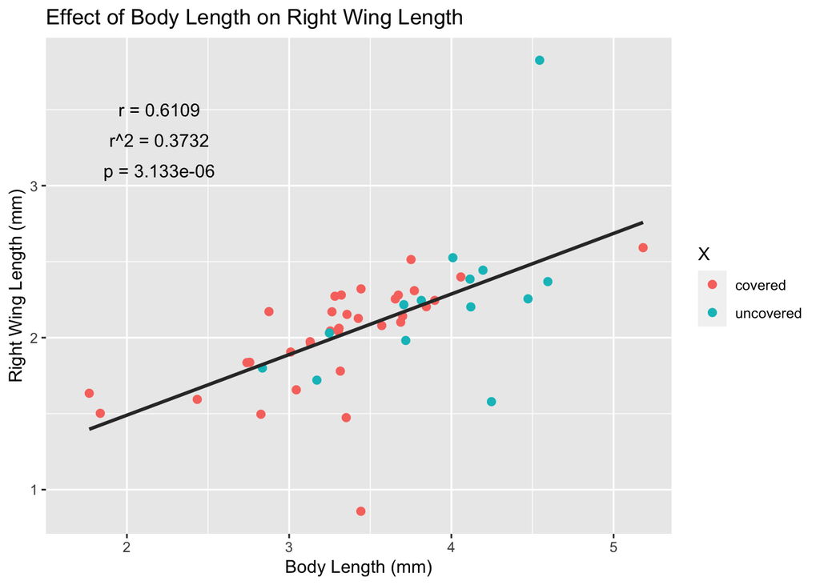

> **Figure 7** Scatterplot of total body length (mm) vs. right wing length (mm) of T. planipennisi. Linear regression line shown in dark grey. Correlation coefficient (r) equals 0.6109. R-squared equals 0.3732. P equals 3.133*10^-6.

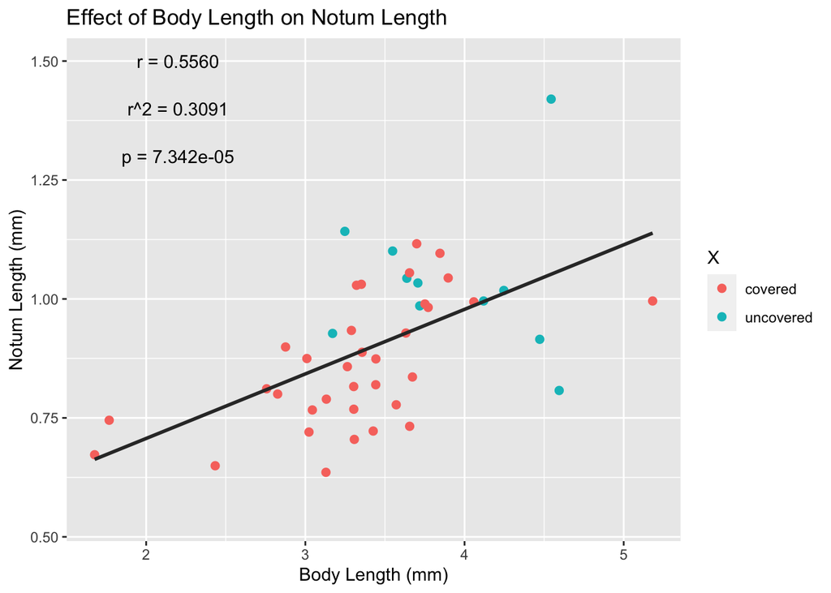

> **Figure 8** Scatterplot of total body length (mm) vs. notum length (mm) of T. planipennisi. Linear regression line shown in dark grey. Correlation coefficient (r) equals 0.5560. R-squared equals 0.3091. P equals 7.342*10^-5.

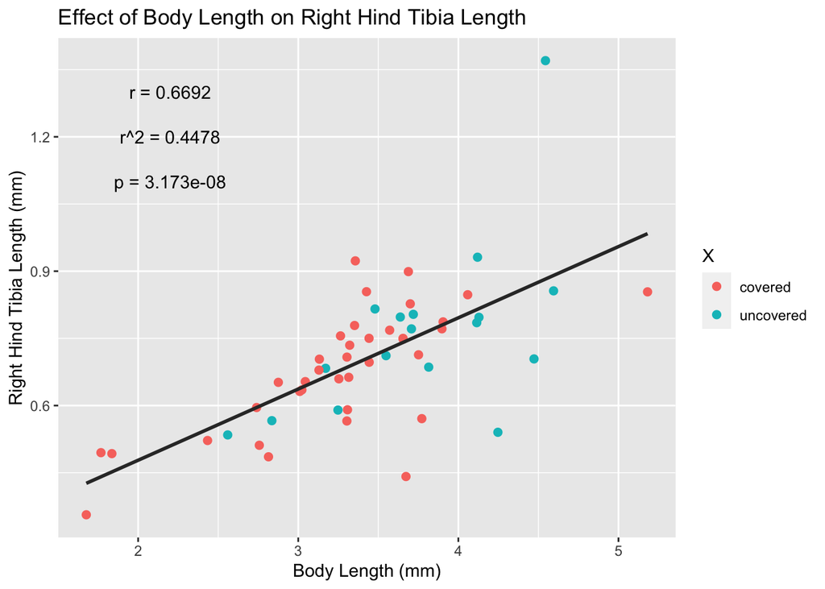

> **Figure 9** Scatterplot of total body length (mm) vs. right hind tibia length (mm) of T. planipennisi. Linear regression line shown in dark grey. Correlation coefficient (r) equals 0.6692. R-squared equals 0.4478. P equals 3.173*10^-8.

# Discussion

In this study, we sought to explore the change in morphologies of T. planipennisi under different experimental conditions after overwintering. Half of the jars were covered, and the other half were left uncovered. Overall, we found that there was a trend of increased body measurements in the uncovered treatment groups when compared to the covered. The notum and total body length measurements showed a significant difference between the two groups. To further our analysis, we explored the relationship between the emergence status of the wasps (collected inside or outside of the ash tree branches) and their morphologies. To our surprise, we found no statistically significant difference in the body measurements between the two emergence states. However, as we will describe alter on, this could be due to a low sample size of unemerged wasps.

We made the null hypotheses that there are no statistically significant differences in the right wing, body, notum, and right hind tibia lengths of T. planipennisi in the covered and uncovered treatment groups. We reject the null hypotheses for the body and notum measurements. Analyses of variance found a statistically significant difference in the mean body (p=0.003) and notum (p=0.00216) lengths between covered and uncovered treatment groups. However, we do not reject the null hypotheses for the mean right wing and right hind tibia lengths. Analyses of variance did not find a statistically significant difference in the mean right wing (p=0.0625) or right hind tibia (p=0.0818) lengths between covered and uncovered treatment groups.

Our second biological hypothesis was not supported in any way, but does beg for further examination. We posited that the biological mechanism behind a difference in morphometrics of wasps collected from inside and outside the branches could be due to their differing stages in the T. planipennisi life cycle. While this was not affirmed in any way, the study of unemergence is significant to understanding the T. planipennisi life cycle. A study of another parasitoid of Emerald Ash Borers called Spathius galinae found that the rates of unemergence were much higher (20%) when reared with host larvae in ash tree branches as opposed to (2.1%) tropical tree branches (Duan et al. 2014). The researchers described how the tropical branches were much more hydrated than to the control ash tree branches by the end of the study. This indicates that the actual branch environment can play a large role in the success of wasp larvae hatching and emergence.

The flaws in this experiment double as opportunity for further study. First, we did not sex the adult wasps upon collection. A study of Leptocybe invasa (eucalyptus gall wasps) found that their sex ratio (p<0.0001) and fecundity (p<0.03) were significantly altered by temperature (Zhu et al. 2014). Given our goal of using T. planipennisi as a biological control agent against Emerald Ash Borer infestation, further study into the effect of temperature on sex allocation of offspring would be valuable. This is especially relevant to Vermont winters, which can be highly variable and liable to unprecedented changes in the face of climate change. Furthermore, the same study concluded that temperature affected L. invasa survivorship at various stages of development (eggs, larva, pupa, and egg-to-adult) differently (p<0.0001). In our study, we could expand our data by comparing survivorship at different stages of T. planipennisi development to the temperature fo the surrounding environment. Then, we could know what temperature encourages the greatest rate of survival of T. planipennisi at different developmental stages. This could inform rearing and life cycle planning in accordance with temperature changes throughout Vermont winters.

Second, we would like to include analysis of wing landmarks in our study. Presently, we took simple wing width and length measurements. A study of wing venation in four genera of the subfamily Vespinae (with a focus on hornets) concluded that variation in wing venation is a highly accurate indicator evolutionary history (Perrard et al. 2014). Interestingly, the results of this study supported the idea that genetic differences between species has a stronger influence on wing shape and venation than other abiotic or biotic factors (Perrard et al. 2014). Furthermore, a multivariate analysis of the forewings of Polistes dominulus (European paper wasp) revealed that wing shapes significantly changes with geographic conditions (Abbasi et al. 2010). Specifically, morphological changes seemed to be tied to the easiest travel distances on a contour map generated by the research team (Abbasi et al. 2010). Many aspects of geographical variations can contribution to population-by-population, and even individual-by-individual changes in wing structure, shape, and venation. Quantitative and computational analyses should be performed on our T. planipennisi samples to verify the degree of difference or relatedness of the wings of these wasps. In future studies, cross-referencing highly detailed wing morphometrics to geographic information (such as elevation, temperature, humidity, etc.) could elucidate the role of environmental factors in wing morphological changes of T. planipennisi in Vermont.

Finally, we often encountered broken ovipositors when trying to collect morphometrics. The nature of the anatomy of T. planipennisi makes this body part very difficult to preserve and measure since it is quite thin. This is extremely important information to have, since ovipositor length plays a crucial role in the ability of insects to lay eggs successfully. The size and shape of Kradibia tentacularis (pollinator fig wasps) is a direct determinant of their ability to reach fig ovaries and lay eggs (Ghana et al. 2017). In our study, T. planipennisi must be able to lay their eggs in the EAB eggs to proliferate and control EAB infestations. Additionally, a study performed on Pteromalus albipennis (Palaearctic parasitoid wasp) suggests that ovipositor length may be a useful indicator of rapid evolution (rather than a hallmark indicator of phylogenetic relatedness) (Maletti et al. 2020). Novel training and protocol may be necessary to improve upon our methodology and obtain higher quality ovipositor morphometrics.

To conclude, we feel confident that further study into morphological changes of T. planipennisi under these experimental conditions will strengthen our understanding of the species as a biological control agent against EAB infestations. The findings of these preliminary analyses have helped us refine our methodology and inform trends in the data. This has provided us with a roadmap for the next stage of investigation into this crucial area of study.

# Acknowledgements

I want to thank George Ni and Professor Nicholas Gotelli for all of the support they have provided throughout my time with them in classes and research. They go above and beyond to create exceptional education experiences for their students and impart as much knowledge as humanly possible to the next generation of scientists. I would also like to thank Christina Anastasia, my fellow undergraduate researcher, for all the time and dedication she has put into this project. This experience has provided me with invaluable skills and information I will use throughout the rest of my career.

# Literature Cited

- Cappaert, D., D.G. McCullough, T.M. Poland, and N.W. Siegert. 2005. Emerald Ash Borer in North America: A Research and Regulatory Challenge. American Entomologist. **51**: 152-165. [https://doi.org/10.1093/ae/51.3.152].
- Bai, Y., J.J. Dong, D.L. Guan, J.Y. Xie, and S.Q. Xu. 2016. Geographic variation in wing size and shape of the grasshopper Trilophidia annulata (Orthoptera: Oedipodidae): morphological trait variations follow an ecogeographical rule. Nature Scientific Reports. **6**: 32680. [https://doi.org/10.1038/srep32680].
- Duan, J.J., T.J. Watt, and K. Larson. 2014. Biology, Life History, and Laboratory Rearing of Spathius galinae (Hymenoptera: Braconidae), a Larval Parasitoid of the Invasive Emerald Ash Borer (Coleoptera: Buprestidae). Journal of Economic Entomology. **107**: 939-946. [https://doi.org/10.1603/EC13552].
- Schwarzfeld, M.D., and F.A. Sperling. 2014. Species delimitation using morphology, morphometrics, and molecules: definition of the Ophion scutellaris Thomson species group, with descriptions of six new species (Hymenoptera, Ichneumonidae). ZooKeys. **462**: 59-114. [https://doi.org/10.3897/zookeys.462.8229].
- Casey, T.M. 1992. Biophysical Ecology and Heat Exchange in Insects. American Zoologist. **32**: 225-237. [https://doi.org/10.1093/icb/32.2.225].
- Csősz, S. B. Seifert, I. Mikó, B.E. Boudinot, M.L. Borowiec, B.L. Fisher, M. Prebus, J. Puniamoorthy, J.C. Rakotonirina, N. Rasoamanana, R. Schultz, C. Trietsch, J.M. Ulmer, and Z. Elek. 2020. Insect morphometry is reproducible under average investigation standards. Ecology and Evolution. **11**: 547-559. [https://doi.org/10.1002/ece3.7075].
- Zhu, F.L, S.X. Ren, B.L. Qiu, and J.H. Wu. 2014. Effect of temperature on life table parameters of Leptocybe invasa (Hymenoptera: Eulophidae). Austral Entomology. **54**: 71-78. [https://doi.org/10.1111/aen.12094].
- Perrard, A., M. Baylac, J.M. Carpenter, and C. Villemant. 2014. Evolution of wing shape in hornets: why is the wing venation efficient for species identification? Journal of Evolutionary Biology. **27**: 2665-2675. [https://doi.org/10.1111/jeb.12523].
- Abbasi, R., M. Mashhadikhan, M. Abbasi, and B. Kiabi. 2010. Geometric morphometric study of populations of the social wasp, Polistes dominulus (Christ, 1791) from Zanjan province, north‐west Iran. New Zealand Journal of Zoology. **36**: 41-46. [https://doi.org/10.1080/03014220909510138].
- Ghana, S., N. Suleman and S.G. Compton. 2017. Style length variation in male and female figs: development, inheritance, and control of pollinator oviposition. Entomologia Experimentalis et Applicata. **162**: 41-50. [https://doi.org/10.1111/eea.12533].
- Maletti, S., O. Niehuis, C. Mayer, M. Sann, S. Klopfstein, G. Nottebrock, H. Baur, and R.S. Peters. 2020. Phylogeny, taxonomics, and ovipositor length variation of the Pteromalus albipennis species group (Hymenoptera: Chalcidoidea: Pteromalidae: Pteromalinae). Journal of Zoological Systematics and Evolutionary Research. **59**: 349-358. [https://doi.org/10.1111/jzs.12433]. (Maletti et al. 2020)
- R Core Team (2023). R: A language and environment for statistical computing. R Foundation for Statistical Computing, Vienna, Austria. URL https://www.R-project.org/.